# **Lab 6: Convolutional Neural Networks**

NOTE: This is a lab project accompanying the following book [MLF] and it should be used together with the book.

[MLF] *H. Jiang*, "[Machine Learning Fundamentals: A Concise Introduction](http://wiki.eecs.yorku.ca/user/hj/research:mlfbook)", Cambridge University Press, 2021. ([bibtex](http://www.cse.yorku.ca/~huijiang/mlf-jiang.bib))

The purpose of this lab is to explore more complex structures in neural networks beyond simple fully-connected networks. In particular, we focus on deep convolutional nerual networks (CNNs) for image classification as CNNs have become the dominant model for many computer vision tasks. Instead of implementing CNNs from scratch as what has been done in the previous Labs, we introduce some popular deep learning toolkits, such as *Tensorflow* and *Pytorch*, and use some examples to show how to use these toolkits to conveniently build various CNN structures and efficiently train/evaluate them with available training/test data.

Prerequisites: N/A

The most important feature in these popular deep learning toolkits (either *Tensorflow* or *Pytorch*) is to provide some flexible ways for us to specify various networks structures. These toolkits usually come up with many different syntaxes from various levels for this purpose. Some low-level syntaxes allow us to conveniently customize neural networks in any way we prefer while other high-level syntaxes offer legible and flexible interfaces to configure popular network structures in the literature. These toolkits allow us to directly use many popular building blocks introduced in [MLF] without reinventing the wheel, such as full connection, convolution, activation, softmax, attension, feedback and normalization layers. On the other hand, it also provides nice interfaces for us to implement any new modules.

Another advantage to use these toolkits is that they come up with automatic differentiation (AD) module so that we do not need to explicitly implement error back-propagation. The learning process is almost totally automatic as long as we specify some key ingredients, such as a loss function, an optimization algorithm and relevant hyperparameters. Finally, these toolkits also provide a full support to allow us to flexibly switch hardware devices between CPUs, GPUs and even TPUs for the training/testing processes.

In this Lab, we only introduce how to use the high-level *Keras* style syntax to build deep convolutional neural networks for image classification tasks. When we use the *Keras* interface to build any complex neural networks, it usually consists of the following three steps:

1. **Define**: we use some highly legible syntax to clearly define the structure of neural networks in a layer by layer manner. In this step, we need to specify all network details in a static structure.
2. **Compile**: we compile the previously defined static network by associating it with some dynamic components, such as a loss function, an optimizer along with its hyperparameters, a hardware device to be used (CPUs or GPUs), an evaluation matric, etc.
3. **Fit**: we fit the compiled model to the available training data (as well as the corresponding target labels). It will run the specified optimizer and use the automatically derived gradients from AD to learn the model on the specified hardware device.

In the following, we will use several examples to show how to do these three steps for convolutional neural networks using *Tensorflow* and *Pytorch*.

## **I. Using TensorFlow**

### **Example 6.1:**

*Use Tensorflow to re-implement the fully-connected neural networks and compare it with various implementations in last Lab in terms of classification accuracy and running speed.*

Here we can use an integer (between 0 and 9) as the target label for each image. For this case, we need to specify the CE loss function as "*sparse_categorical_crossentropy*" in *Tensorflow*. If we use the one-hot vector as the target label for each image, we need to specify the CE loss function as "*categorical_crossentropy*" in *Tensorflow*. Note that *Tensorflow* uses GPUs by default as long as GPUs are available.

```python
!pip install fsspec
!pip install -U -q datasets
```

[output not shown]

```python
#load MINST images

from datasets import load_dataset
import numpy as np

trainset = load_dataset('mnist', split='train')
train_data = trainset['image']
train_label = trainset['label']

testset = load_dataset('mnist', split='test')
test_data = testset['image']
test_label = testset['label']

train_data = np.array(train_data, dtype='float')/255 # norm to [0,1]
train_data = np.reshape(train_data,(60000,28*28))
y_train = np.array(train_label, dtype='short')
test_data = np.array(test_data, dtype='float')/255 # norm to [0,1]
test_data = np.reshape(test_data,(10000,28*28))
y_test = np.array(test_label, dtype='short')

#reshape each input vector (784) into a 28*28*1 image
X_train = np.reshape(train_data, (-1,28,28,1))
X_test = np.reshape(test_data, (-1,28,28,1))

# convert MNIST labels into 10-D one-hot vectors
Y_train = np.zeros((y_train.size, y_train.max()+1))
Y_train[np.arange(y_train.size),y_train] = 1
Y_test = np.zeros((y_test.size, y_test.max()+1))
Y_test[np.arange(y_test.size),y_test] = 1

print(X_train.shape, y_train.shape, X_test.shape, y_test.shape, Y_train.shape, Y_test.shape)
```

```
(60000, 28, 28, 1) (60000,) (10000, 28, 28, 1) (10000,) (60000, 10) (10000, 10)
```

```python
# use tensorflow to implement a fully-connected neural networks (same structure as Lab5)
#
# use integers as target labels and specify CE loss as "sparse_categorical_crossentropy"

import numpy as np
import tensorflow as tf
from tensorflow import keras

tf.random.set_seed(42)
np.random.seed(42)

# define the model structure using Keras
model = keras.models.Sequential([
    keras.layers.Flatten(input_shape=[28,28]),
    keras.layers.Dense(500, activation="relu"),
    keras.layers.Dense(250, activation="relu"),
    keras.layers.Dense(10, activation="softmax")
])

# compile model by attaching with loss/optimizer/metric
model.compile(loss="sparse_categorical_crossentropy",      # CE loss for integer label
              optimizer=keras.optimizers.SGD(learning_rate=1e-1),
              metrics=["accuracy"])

# fit to training data to learn the model
history = model.fit(X_train, y_train, epochs=10,          # y_train: integer labels
                    validation_data=(X_test, y_test))     # y_test: integer labels
```

```python
# use tensorflow to implement a fully-connected neural networks
# use one-hot target labels and specify CE loss as "categorical_crossentropy"

import numpy as np
import tensorflow as tf
from tensorflow import keras

tf.random.set_seed(42)
np.random.seed(42)

# define the model structure using Keras  (same network structure as Lab5)
model = keras.models.Sequential([
    keras.layers.Flatten(input_shape=[28,28]),
    keras.layers.Dense(500, activation="relu"),
    keras.layers.Dense(250, activation="relu"),
    keras.layers.Dense(10, activation="softmax")
])

# compile model by attaching with loss/optimizer/metric
model.compile(loss="categorical_crossentropy",      # CE loss for one-hot vector label
              optimizer=keras.optimizers.SGD(learning_rate=1e-1),
              metrics=["accuracy"])

# fit to training data to learn the model
history = model.fit(X_train, Y_train, epochs=10,        # Y_train: one-hot vector labels
                    validation_data=(X_test, Y_test))   # Y_test: one-hot vector labels
```

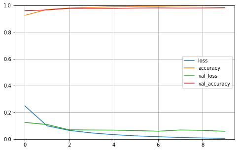

```python
# show the learning curves
import pandas as pd
import matplotlib.pyplot as plt

pd.DataFrame(history.history).plot(figsize=(8, 5))
plt.grid(True)
plt.gca().set_ylim(0, 1)
plt.show()
```

```python
model.summary()
```

```
Model: "sequential_2"
_________________________________________________________________
 Layer (type)                Output Shape              Param #
=================================================================
 flatten_2 (Flatten)         (None, 784)               0

 dense_6 (Dense)             (None, 500)               392500

 dense_7 (Dense)             (None, 250)               125250

 dense_8 (Dense)             (None, 10)                2510

=================================================================
Total params: 520,260
Trainable params: 520,260
Non-trainable params: 0
_________________________________________________________________
```

```python
# show the GPU type used in the above computation

!nvidia-smi
```

```
Wed Dec  4 16:06:21 2024
+---------------------------------------------------------------------------------------+
| NVIDIA-SMI 535.104.05             Driver Version: 535.104.05   CUDA Version: 12.2     |
|-----------------------------------------+----------------------+----------------------+
| GPU  Name                 Persistence-M | Bus-Id        Disp.A | Volatile Uncorr. ECC |
| Fan  Temp   Perf          Pwr:Usage/Cap |         Memory-Usage | GPU-Util  Compute M. |
|                                         |                      |               MIG M. |
|=========================================+======================+======================|
|   0  Tesla T4                       Off | 00000000:00:04.0 Off |                    0 |
| N/A   39C    P8               9W /  70W |      0MiB / 15360MiB |      0%      Default |
|                                         |                      |                  N/A |
+-----------------------------------------+----------------------+----------------------+

+---------------------------------------------------------------------------------------+
| Processes:                                                                            |
|  GPU   GI   CI        PID   Type   Process name                            GPU Memory |
|        ID   ID                                                             Usage      |
|=======================================================================================|
|  No running processes found                                                           |
+---------------------------------------------------------------------------------------+
```

### **Example 6.2:**

*Use Tensorflow to implement the convolutional neural networks as structrued on page 200, and evaluate its performance using the MNIST data set and compare it with the fully-connected neural networks in the previous example.*

```python
# use tensorflow to implement a convolutional neural network on page 200

import numpy as np
import tensorflow as tf
from tensorflow import keras

tf.random.set_seed(42)
np.random.seed(42)

# define the model structure using Keras
model = keras.models.Sequential([
    keras.layers.Conv2D(filters=32, kernel_size=3, activation='relu', \
                        padding='same', input_shape=[28, 28, 1]),
    keras.layers.Conv2D(filters=64, kernel_size=3, activation='relu', padding='same'),
    keras.layers.Conv2D(filters=64, kernel_size=3, activation='relu', padding='same'),
    keras.layers.MaxPooling2D(pool_size=2),
    keras.layers.Flatten(),
    keras.layers.Dense(units=7744, activation='relu'),
    keras.layers.Dense(units=128, activation='relu'),
    keras.layers.Dense(units=10, activation='softmax'),
])

# compile model by attaching loss/optimizer/metric components
model.compile(loss="sparse_categorical_crossentropy",
              optimizer=keras.optimizers.SGD(learning_rate=3e-2),
              metrics=["accuracy"])

# learning a model
history = model.fit(X_train, y_train, epochs=10,
                    validation_data=(X_test, y_test))
```

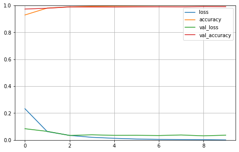

```python
# show the learning curves
import pandas as pd
import matplotlib.pyplot as plt

pd.DataFrame(history.history).plot(figsize=(8, 5))
plt.grid(True)
plt.gca().set_ylim(0, 1)
plt.show()
```

From the above results, we can see that this simple CNN yields better performance than FCNNs as its best classification accuracy on the test set is 99.13%.

In the above implementation, *padding='same'* indciates that proper zero-paddings are added prior to convolution so that the generated outputs have the same dimensions as the inputs. This is clear from the following model summary:

```python
model.summary()
```

```
Model: "sequential_11"
_________________________________________________________________
 Layer (type)                Output Shape              Param #
=================================================================
 conv2d_49 (Conv2D)          (None, 28, 28, 32)        320

 conv2d_50 (Conv2D)          (None, 28, 28, 64)        18496

 conv2d_51 (Conv2D)          (None, 28, 28, 64)        36928

 max_pooling2d_29 (MaxPoolin  (None, 14, 14, 64)       0
 g2D)

 flatten_11 (Flatten)        (None, 12544)             0

 dense_33 (Dense)            (None, 7744)              97148480

 dense_34 (Dense)            (None, 128)               991360

 dense_35 (Dense)            (None, 10)                1290

=================================================================
Total params: 98,196,874
Trainable params: 98,196,874
Non-trainable params: 0
_________________________________________________________________
```

### **Example 6.3:**

*Use Tensorflow to implement a deeper convolutional neural networks as in Figure 8.23 on page 169, and evaluate its performance using the MNIST data set.*

```python
# use tensorflow to implement a convolutional neural networks in Figure 8.23 on page 169

import numpy as np
import tensorflow as tf
from tensorflow import keras

tf.random.set_seed(42)
np.random.seed(42)

# define the model structure using Keras
model = keras.models.Sequential([
    keras.layers.Conv2D(filters=64, kernel_size=3, activation='relu', \
                        padding='same', input_shape=[28, 28, 1]),
    keras.layers.Conv2D(filters=64, kernel_size=3, activation='relu', padding='same'),
    keras.layers.MaxPooling2D(pool_size=2),
    keras.layers.Conv2D(filters=128, kernel_size=3, activation='relu', padding='same'),
    keras.layers.Conv2D(filters=128, kernel_size=3, activation='relu', padding='same'),
    keras.layers.MaxPooling2D(pool_size=2),
    keras.layers.Conv2D(filters=256, kernel_size=3, activation='relu', padding='same'),
    keras.layers.Conv2D(filters=256, kernel_size=3, activation='relu', padding='same'),
    keras.layers.Conv2D(filters=256, kernel_size=3, activation='relu', padding='same'),
    keras.layers.MaxPooling2D(pool_size=2),
    keras.layers.Flatten(),
    keras.layers.Dense(units=4096, activation='relu'),
    keras.layers.Dense(units=4096, activation='relu'),
    keras.layers.Dense(units=1000, activation='relu'),
    keras.layers.Dense(units=10, activation='softmax'),
])

# compile model by attaching with loss/optimizer/metric
model.compile(loss="sparse_categorical_crossentropy",
              optimizer=keras.optimizers.SGD(learning_rate=5e-2),
              metrics=["accuracy"])

# learning a model
history = model.fit(X_train, y_train, epochs=10,
                    validation_data=(X_test, y_test))
```

```python
model.summary()
```

```
Model: "sequential_6"
_________________________________________________________________
 Layer (type)                Output Shape              Param #
=================================================================
 conv2d_3 (Conv2D)           (None, 28, 28, 64)        640

 conv2d_4 (Conv2D)           (None, 28, 28, 64)        36928

 max_pooling2d_1 (MaxPooling  (None, 14, 14, 64)       0
 2D)

 conv2d_5 (Conv2D)           (None, 14, 14, 128)       73856

 conv2d_6 (Conv2D)           (None, 14, 14, 128)       147584

 max_pooling2d_2 (MaxPooling  (None, 7, 7, 128)        0
 2D)

 conv2d_7 (Conv2D)           (None, 7, 7, 256)         295168

 conv2d_8 (Conv2D)           (None, 7, 7, 256)         590080

 conv2d_9 (Conv2D)           (None, 7, 7, 256)         590080

 max_pooling2d_3 (MaxPooling  (None, 3, 3, 256)        0
 2D)

 flatten_6 (Flatten)         (None, 2304)              0

 dense_18 (Dense)            (None, 4096)              9441280

 dense_19 (Dense)            (None, 4096)              16781312

 dense_20 (Dense)            (None, 1000)              4097000

 dense_21 (Dense)            (None, 10)                10010

=================================================================
Total params: 32,063,938
Trainable params: 32,063,938
Non-trainable params: 0
_________________________________________________________________
```

## **II. Using Pytorch**

In general, *Pytorch* follows a similar pipeline of model construction as *Tensorflow*. Refer to an online [Tutorial](https://pytorch.org/tutorials/beginner/basics/quickstart_tutorial.html) for more details. In the following examples, we use a keras-style package for Pytorch, namely *torchkeras*. As a result, we can similarly follow the above three steps in building CNNs using *Pytorch*.

### **Example 6.4:**

```python
# Convert training/test data from numpy arrays to pytorch tensors/datasets
import torch
import numpy as np
from torch.utils.data import TensorDataset, DataLoader

X_train_ts = torch.Tensor(X_train.reshape(-1,1,28,28))
train_dataset = torch.utils.data.TensorDataset(X_train_ts, torch.Tensor(y_train).long())
X_test_ts = torch.Tensor(X_test.reshape(-1,1,28,28))
test_dataset = torch.utils.data.TensorDataset(X_test_ts, torch.Tensor(y_test).long())

dl_train =  torch.utils.data.DataLoader(train_dataset, batch_size=32, shuffle=True, num_workers=2)
dl_valid =  torch.utils.data.DataLoader(test_dataset, batch_size=32, shuffle=False, num_workers=2)

print(len(dl_train))
print(len(dl_valid))
```

```
1875
313
```

```python
import torch
import torch.nn as nn
import torch.nn.functional as F
import torch.optim as optim
from torchvision import datasets, transforms
from torch.optim.lr_scheduler import StepLR

# define CNN structure and its forward pass layer-by-layer
class Net(nn.Module):
    def __init__(self):
        super().__init__()
        self.layers = nn.ModuleList([
            nn.Conv2d(in_channels=1,out_channels=32,kernel_size = 3),
            nn.ReLU(),
            nn.Conv2d(in_channels=32,out_channels=64,kernel_size = 3),
            nn.ReLU(),
            nn.Conv2d(in_channels=64,out_channels=64,kernel_size = 3),
            nn.ReLU(),
            nn.MaxPool2d(kernel_size = 2,stride = 2),
            nn.Flatten(),
            nn.Linear(7744,128),
            nn.ReLU(),
            nn.Linear(128,10),
            nn.Softmax(dim=1)
            ]
        )
    def forward(self,x):
        for layer in self.layers:
            x = layer(x)
        return x

def train(model, device, train_loader, optimizer, epoch):
    model.train()
    for batch_idx, (data, target) in enumerate(train_loader):
        data, target = data.to(device), target.to(device)
        optimizer.zero_grad()
        output = model(data)
        #loss = F.cross_entropy(output, target)
        loss = F.nll_loss(torch.log(output), target)
        loss.backward()
        optimizer.step()
        if batch_idx % 1000 == 0:
            print('Train Epoch: {} [{}/{} ({:.0f}%)]\tLoss: {:.6f}'.format(
                epoch, batch_idx * len(data), len(train_loader.dataset),
                100. * batch_idx / len(train_loader), loss.item()))


def test(model, device, test_loader):
    model.eval()
    test_loss = 0
    correct = 0
    with torch.no_grad():
        for data, target in test_loader:
            data, target = data.to(device), target.to(device)
            output = model(data)
            test_loss += F.nll_loss(torch.log(output), target, reduction='sum').item()  # sum up batch loss
            pred = output.argmax(dim=1, keepdim=True)  # get the index of the max log-probability
            correct += pred.eq(target.view_as(pred)).sum().item()

    test_loss /= len(test_loader.dataset)

    print('\nTest set: Average loss: {:.4f}, Accuracy: {}/{} ({:.0f}%)\n'.format(
        test_loss, correct, len(test_loader.dataset),
        100. * correct / len(test_loader.dataset)))
```

```python
# use pyorch to implement a convolutional neural networks on page 200
device = torch.device("cuda")
#device = torch.device("cpu")

model = Net().to(device)

#optimizer = optim.Adadelta(model.parameters(), lr=0.1)
optimizer= torch.optim.SGD(model.parameters(), lr=0.1)
scheduler = StepLR(optimizer, step_size=1, gamma=0.9)

for epoch in range(1, 11):
  train(model, device, dl_train, optimizer, epoch)
  test(model, device, dl_valid)
  scheduler.step()
```

```
Train Epoch: 1 [0/60000 (0%)]	Loss: 2.296348
Train Epoch: 1 [32000/60000 (53%)]	Loss: 0.017146

Test set: Average loss: 0.0464, Accuracy: 9855/10000 (99%)

Train Epoch: 2 [0/60000 (0%)]	Loss: 0.030179
Train Epoch: 2 [32000/60000 (53%)]	Loss: 0.025975

Test set: Average loss: 0.0390, Accuracy: 9867/10000 (99%)

Train Epoch: 3 [0/60000 (0%)]	Loss: 0.035469
Train Epoch: 3 [32000/60000 (53%)]	Loss: 0.030731

Test set: Average loss: 0.0345, Accuracy: 9892/10000 (99%)

Train Epoch: 4 [0/60000 (0%)]	Loss: 0.004104
Train Epoch: 4 [32000/60000 (53%)]	Loss: 0.002806

Test set: Average loss: 0.0358, Accuracy: 9892/10000 (99%)

Train Epoch: 5 [0/60000 (0%)]	Loss: 0.004121
Train Epoch: 5 [32000/60000 (53%)]	Loss: 0.000053

Test set: Average loss: 0.0364, Accuracy: 9897/10000 (99%)

Train Epoch: 6 [0/60000 (0%)]	Loss: 0.002082
Train Epoch: 6 [32000/60000 (53%)]	Loss: 0.000066

Test set: Average loss: 0.0361, Accuracy: 9907/10000 (99%)

Train Epoch: 7 [0/60000 (0%)]	Loss: 0.000393
Train Epoch: 7 [32000/60000 (53%)]	Loss: 0.000032

Test set: Average loss: 0.0383, Accuracy: 9905/10000 (99%)

Train Epoch: 8 [0/60000 (0%)]	Loss: 0.000496
Train Epoch: 8 [32000/60000 (53%)]	Loss: 0.000038

Test set: Average loss: 0.0366, Accuracy: 9919/10000 (99%)

Train Epoch: 9 [0/60000 (0%)]	Loss: 0.000150
Train Epoch: 9 [32000/60000 (53%)]	Loss: 0.000004

Test set: Average loss: 0.0388, Accuracy: 9916/10000 (99%)

Train Epoch: 10 [0/60000 (0%)]	Loss: 0.000003
Train Epoch: 10 [32000/60000 (53%)]	Loss: 0.000158

Test set: Average loss: 0.0409, Accuracy: 9918/10000 (99%)
```

### **Example 6.5:**

*Use Pytorch's Keras wrapper, `torchkeras`, to re-implement the convolutional neural networks as Example 6.4, and evaluate its performance using the MNIST data set.*

```python
# install keras packages for pytorch

!pip install -U torchkeras
```

```
Downloading torchkeras-4.0.2-py3-none-any.whl (6.6 MB)
   ━━━━━━━━━━━━━━━━━━━━━━━━━━━━━━━━━━━━━━━━ 6.6/6.6 MB 37.9 MB/s eta 0:00:00
```

```python
# use pyorch to implement a convolutional neural networks on page 200
import torch
from torch import nn

# define CNN structure and its forward pass layer-by-layer
class CnnModel(nn.Module):
    def __init__(self):
        super().__init__()
        self.layers = nn.ModuleList([
            nn.Conv2d(in_channels=1,out_channels=32,kernel_size = 3),
            nn.ReLU(),
            nn.Conv2d(in_channels=32,out_channels=64,kernel_size = 3),
            nn.ReLU(),
            nn.Conv2d(in_channels=64,out_channels=64,kernel_size = 3),
            nn.ReLU(),
            nn.MaxPool2d(kernel_size = 2,stride = 2),
            nn.Flatten(),
            nn.Linear(7744,128),
            nn.ReLU(),
            nn.Linear(128,10),
            nn.LogSoftmax(dim=1)
            ]
        )
    def forward(self,x):
        for layer in self.layers:
            x = layer(x)
        return x
```

```
<<<<<< ⚡️ cuda is used >>>>>>
```

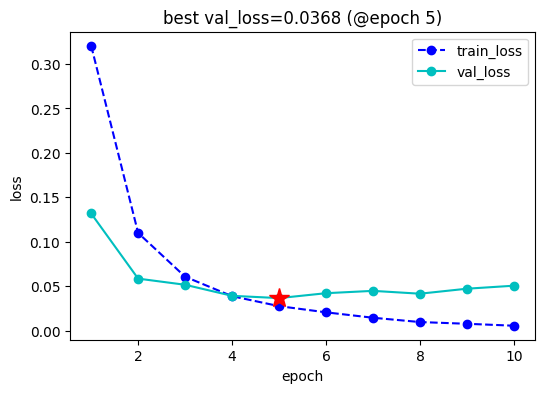

100% [10/10] [03:32]  
████████████████████100.00% [313/313] [val_loss=0.0507, val_acc=0.9890]

```python
# running CNNs
import torchkeras

# define the metrics computed during the learnin process
class Accuracy(nn.Module):
    def __init__(self):
        super().__init__()

        self.correct = nn.Parameter(torch.tensor(0.0),requires_grad=False)
        self.total = nn.Parameter(torch.tensor(0.0),requires_grad=False)

    def forward(self, preds: torch.Tensor, targets: torch.Tensor):
        preds = preds.argmax(dim=-1)
        m = (preds == targets).sum()
        n = targets.shape[0]
        self.correct += m
        self.total += n

        return m/n

    def compute(self):
        return self.correct.float() / self.total

    def reset(self):
        self.correct -= self.correct
        self.total -= self.total

# compile the model by attaching various dynamic components
net = CnnModel()
model = torchkeras.KerasModel(net,
                              loss_fn = nn.NLLLoss(),
                              optimizer= torch.optim.SGD(net.parameters(), lr=0.1),
                              scheduler = StepLR(optimizer, step_size=1, gamma=0.9),
                              metrics_dict = {"acc":Accuracy()}
                              )

# train CNNs by fitting to the training data
dfhistory=model.fit(train_data=dl_train,
                    val_data=dl_valid,
                    epochs=10
                   )
```

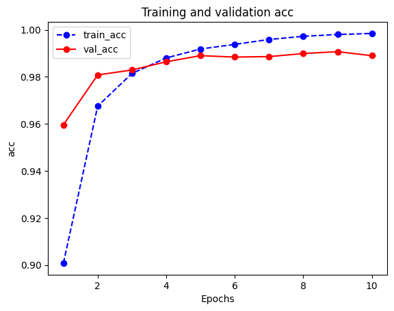

```
0    0.900783
1    0.967533
2    0.981433
3    0.988033
4    0.991833
5    0.993800
6    0.995883
7    0.997233
8    0.998000
9    0.998450
Name: train_acc, dtype: float64
0    0.9596
1    0.9808
2    0.9829
3    0.9864
4    0.9890
5    0.9884
6    0.9886
7    0.9899
8    0.9907
9    0.9890
Name: val_acc, dtype: float64
0.998449981212616 0.9907000064849854
```

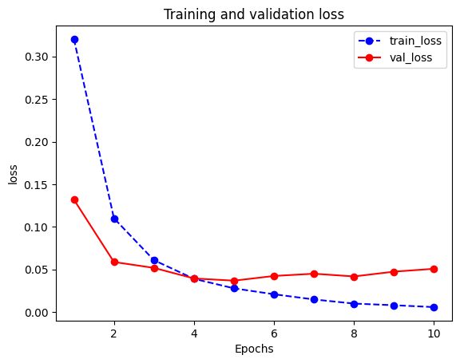

```
0.005767303923753817 0.03680578874346261
```

```python
# retrieve data from training history to plot learning curves
#
import matplotlib.pyplot as plt

def plot_metric(dfhistory, metric):
    train_metrics = dfhistory["train_"+metric]
    val_metrics = dfhistory['val_'+metric]
    epochs = range(1, len(train_metrics) + 1)
    plt.plot(epochs, train_metrics, 'bo--')
    plt.plot(epochs, val_metrics, 'ro-')
    plt.title('Training and validation '+ metric)
    plt.xlabel("Epochs")
    plt.ylabel(metric)
    plt.legend(["train_"+metric, 'val_'+metric])
    plt.show()

# retrieve and plot the accuracy curves
plot_metric(dfhistory,'acc')
print(dfhistory["train_acc"])
print(dfhistory["val_acc"])
print(dfhistory["train_acc"].max(), dfhistory['val_acc'].max())


# retrieve and plot the loss curves
plot_metric(dfhistory,'loss')
#print(dfhistory["train_loss"])
#print(dfhistory["val_loss"])
print(dfhistory["train_loss"].min(), dfhistory['val_loss'].min())
```

```python
# evaluate model

model.evaluate(dl_valid,quiet=False)
```

```
{'val_loss': 0.03680578874346261, 'val_acc': 0.9890000224113464}
```

## **Exercises**

### **Problem 6.1:**

Use *Tensorflow* or *Pytorch* to implement a CNN model as in Figure 8.23 on page 169 and evaluate it on [the CIFAR10 data set](https://www.cs.toronto.edu/~kriz/cifar.html). Vary the structures in this CNN model slightly to see whether you can further improve the performance on the CIFAR10 test set.

### **Problem 6.2:**

Use *JAX* and its automatic differenttiation to implement CNNs from scratch. Use your implementation to build the same CNN model as in Example 6.2 and evaluate it on the MNIST data set. Compare your *JAX* implementation with *TensorFlow* or *Pytorch* in terms of classification accuracy and running speed.